# Asa Watten

# Energy and environmental economist

### [cv](https://www.dropbox.com/scl/fi/wqc9ny1b6t4ajq100w9ek/CV.pdf?rlkey=cxvbaoe21tyuhbi3rtdfan0s1&dl=0) ⋅ research ⋅ contact

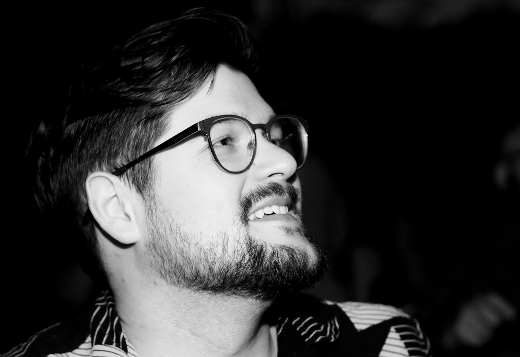

I am an economist and post-doc at [Yale School of the Environment](https://environment.yale.edu/). My current interests revolve around the development and adoption of technologies that mitigate climate change. In particular I am interested in how uncertainty affects economic and political decisions about these technologies. How fast and in what direction will innovation move? How will policy change in the future? How will people react to new technologies? I use a combination of economic modeling and causal inference to investigate these questions.

Prior to Yale, I was a research fellow at the Environmental Protection Agency where I worked on cars, including [light and medium-duty vehicle rule making](https://www.epa.gov/regulations-emissions-vehicles-and-engines/proposed-rule-multi-pollutant-emissions-standards-model), and environmental justice questions. I earned my Ph.D. in [Agricultural, Food, and Resource Economics](https://afre.msu.edu) at Michigan State University. I also hold degrees from The University of Chicago and Carnegie Mellon University. Before graduate school, I ran a small biofuel company in Braddock, Pennsylvania.

Details.

Now famously the home of Senator John Fetterman who was [mayor at the time.](https://www.rollingstone.com/culture/culture-features/john-fetterman-pennsylvania-mayor-hell-allegheny-county-100493/)

# Upcoming/recent presentations

⋅ ASSA 2024 Annual Meeting  
⋅ NBER Economics of Energy Use in Transportation [[slides]](https://www.dropbox.com/scl/fi/stcehaxycwbwofk6izotu/Attributes-NBER.pdf?rlkey=7wpfb2f4ga2xgzu7rxd03lygh&dl=0)

# Research

## Peer-reviewed

How is Rooftop Solar Capitalized in Home Prices? With Kenneth Gillingham. R&R at Regional Science and Urban Economics. [[Working paper]](https://www.dropbox.com/scl/fi/ccz50ie7jv95i76k1km8o/Gillingham-and-Watten-Solar-Capitalization.pdf?rlkey=36ity4d1svi1khopqssj9ni5r&dl=0).

Key figure. Full solar capitalization assumes a high discount rate.

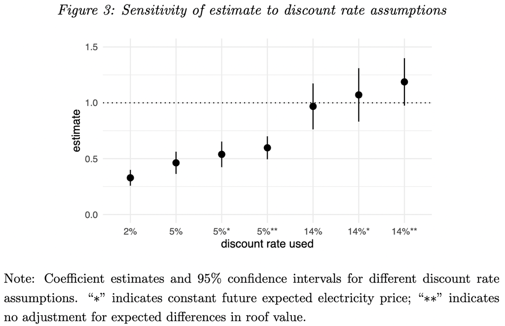

## Working papers

Attribute Production and Technical Change in Automobiles. 2023. With Soren Anderson and Gloria Helfand. [[NBER]](https://conference.nber.org/conf_papers/f178120.pdf)

Key figure. Estimated technical change is substantially fuel-economy biased (left). Consumer preferences for size, acceleration, and fuel economy have all increaed (right).

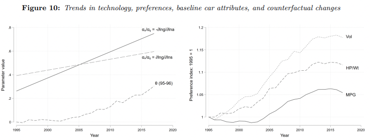

Political Risk Reduces Solar Adoption in Renewable Portfolio Standards. 2022. [[Slides]](https://www.dropbox.com/scl/fi/2k3e1eh86bsox7rnvmigz/Watten_AERE_2022.pdf?rlkey=wyhl3h35cfv05ia5gcoo4odn8&dl=0)

Dissertation chapter.

## Works in progress

Co-adoption of Rooftop Solar and Electric Vehicles. With Bryan Bollinger and Kenneth Gillingham.

DOE grant funded.

Green vs Grid-independence Messaging: Evidence from a Residential Battery Storage Field Experiment. With Bryan Bollinger and Kenneth Gillingham.

Ibid.

Against the Wind? Hedonic Estimation Under Attribute Uncertainty.

# Contact

asa.watten + yale.edu  
Pronunciation: Ace-uh.

```
Last update: 2023-09-11
```